# Act_report

## emmamutegi97@gmail.com

## Alogarithms confidence in prediction

### A Confidence Score is a number between 0 and 1 that represents the likelihood that the output of a Algorithms model is correct and will satisfy a user's request and needs

### The rate at which the an algorithms can be able to predict a dog when fitted with images and tell us more about the model worked. Prediction 1 has a mean 0.5 and at some point it 1 indicating a complete sucess.Algorithms plays a big role in predictive machine learning

### Prediction2 and prediction3 have outliers which mean during of fitting of these algorithms with data or images they "overperformed" as well "underperforming" in relation to where the bulk of the rest data was. When outliers affect our algorithm, they are called influential points, the univariate method, the multivariate method and the Minkowski error are differents methods of dealing with outliers

### prediction1_confidence is left skewed and prediction2 and prediction3 are right skewed: Data skewed to the right is usually a result of a lower boundary in a data set (whereas data skewed to the left is a result of a higher boundary). When data set's lower bounds are extremely low relative to the rest of the data, this will cause the data to skew right

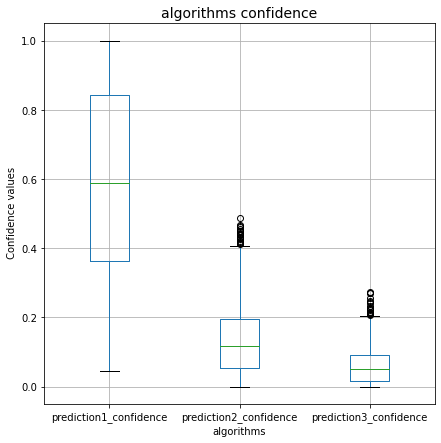

## Distribution of dog stages

### People in general will invest and spend more on pupper dogs than any other stages : having seen the amount of pupper posted one can make a bussiness decision to invest on them since they command a high demand than the rest

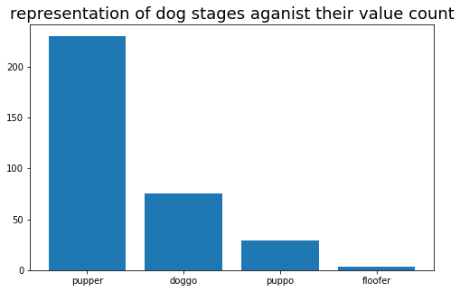

## Dog stage popurality in respect to retweet and favorite counts and their sources

### Most people tweeted using iphone indicating that the most valued gadget is iphone among dog lovers in our data: A production company or an investor can make a decision of buying a stock in apple company since it has a very good bussiness trend among other sources seen in our visualization

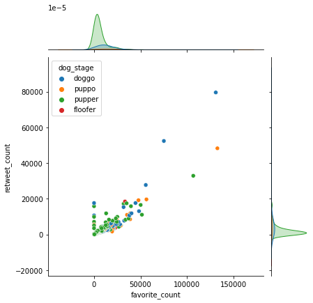

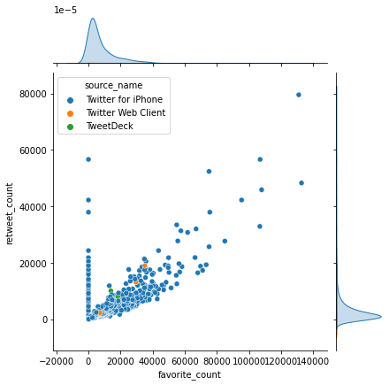